# Part II - Fordgobike-Tripdata Explanatory

## by David G. AKPOVI

## Investigation Overview

## Key Insights for Presentation

> **The duration of most of the bike trips doesn’t last more than 30 mn.** Duration of a trip is an important data for the bike trip service. I focused on it to know the average. In this dataset, the duration was in seconds. When I tried to do an univariate exploration, it showed me a visualization which was hard to interpret. I had to convert the duration in seconds into minutes. To do that, I divide the duration by 60. The visualization I obtained was more cleared. It showed me that more than 160000 users have bike ride duration between, approximately, 1 mn and 23 mn. Most of the trip bike don’t exceed more than 30 mn.

> **The bike trip service has more subscribers than customers.** I found this data very important for this service because it is essential to know what people use the service. To find out, I used a “countplot” with user type as variable. It showed me that approximately 160000 people are subscribers and less than 20000 people are customers.

> **All genders subscribers have less service usage duration in minutes than customers.** To find out this data, I used a multivariate exploration between member_gender, duration_min and user_type. It gave a data visualization in two parts. One part showed the duration in minutes for customers of all genders and the other part showed the duration in minutes for subscribers. We can see on the visualization that for customers, duration for male is approximately 20 minutes, 23 minutes for females and more than 25 minutes for other genders. For subscribers, males average duration is less than 10 minutes, for females is a little above than 10 minutes and for the other is approximately 15 minutes.

## Dataset Overview

> The dataset I choose is called Fordgobike-Tripdata. This dataset includes information about individual rides made in a bike-sharing system covering the greater San Francisco Bay area. Fordgobike-Tripdata is a bike-sharing system where people can borrow a bike to go where they want. They can be customer or subscriber.

## Visualization 1: The duration of most of the bike trips doesn’t last more than 30 mn

> Duration of a trip is an important data for the bike trip service. I focused on it to know the average. In this dataset, the duration was in seconds. When I tried to do an univariate exploration, it showed me a visualization which was hard to interpret. I had to convert the duration in seconds into minutes. To do that, I divide the duration by 60. The visualization I obtained was more cleared. It showed me that more than 160000 users have bike ride duration between, approximately, 1 mn and 23 mn. Most of the trip bike don’t exceed more than 30 mn.

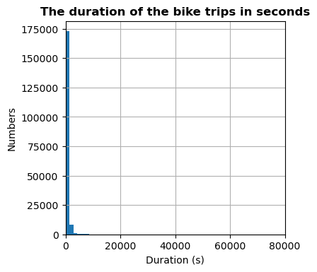

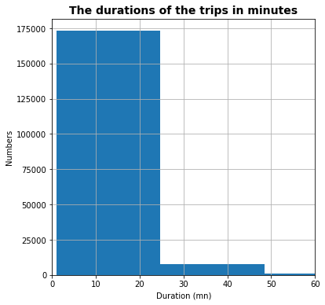

## Visualization 2: The bike trip service has more subscribers than customers

> I found this data very important for this service because it is essential to know what people use the service. To find out, I used a “countplot” with user type as variable. It showed me that approximately 160000 people are subscribers and less than 20000 people are customers.

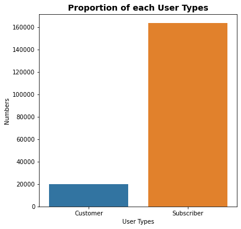

## Visualization 3 : All genders subscribers have less service usage duration in minutes than customers

> **.** To find out this data, I used a multivariate exploration between member_gender, duration_min and user_type. It gave a data visualization in two parts. One part showed the duration in minutes for customers of all genders and the other part showed the duration in minutes for subscribers. We can see on the visualization that for customers, duration for male is approximately 20 minutes, 23 minutes for females and more than 25 minutes for other genders. For subscribers, males average duration is less than 10 minutes, for females is a little above than 10 minutes and for the other is approximately 15 minutes.

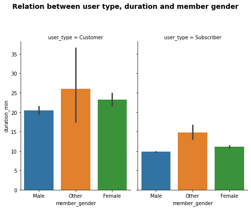